# Dialogues in the comedy TV show Seinfeld: A show about nothing!

**This project analyses my favourite comedy TV show Seinfeld. I created this project to practice exploratory data analysis, visualization and natural language processing of dialogues in Seinfeld.**

The data consists of 54616 rows and 6 columns. Column information:

1. Unnamed: 0 - index column
2. Character - name of the character in the TV show
3. Dialogue - quotes from show's dialogues
4. EpisodeNo - episode number
5. SEID - Season and episode ID (i.e. S01E01 denotes 1st episode of the 1st season)
6. Season - number of show's season

### Load packages required for the project

```python
import numpy as np
import pandas as pd
import matplotlib.pyplot as plt
import matplotlib.pylab as pylab
import seaborn as sns
pd.options.mode.chained_assignment = None
import IPython
from IPython import display #pretty printing of dataframes in Jupyter notebook
import warnings #Ignore warnings
warnings.filterwarnings('ignore')
#Configure Visualization Defaults
#%matplotlib inline = show plots in Jupyter Notebook browser
%matplotlib inline
plt.style.use('ggplot')
sns.set_style('white')
pylab.rcParams['figure.figsize'] = 12,8
```

```python
# Load data and show the first 10 rows
df = pd.read_csv('~/Desktop/scripts.csv', index_col=0)
df.head(10)
```

|  | Character | Dialogue | EpisodeNo | SEID | Season |
| --- | --- | --- | --- | --- | --- |
| 0 | JERRY | Do you know what this is all about? Do you kno... | 1.0 | S01E01 | 1.0 |
| 1 | JERRY | (pointing at Georges shirt) See, to me, that b... | 1.0 | S01E01 | 1.0 |
| 2 | GEORGE | Are you through? | 1.0 | S01E01 | 1.0 |
| 3 | JERRY | You do of course try on, when you buy? | 1.0 | S01E01 | 1.0 |
| 4 | GEORGE | Yes, it was purple, I liked it, I dont actuall... | 1.0 | S01E01 | 1.0 |
| 5 | JERRY | Oh, you dont recall? | 1.0 | S01E01 | 1.0 |
| 6 | GEORGE | (on an imaginary microphone) Uh, no, not at th... | 1.0 | S01E01 | 1.0 |
| 7 | JERRY | Well, senator, Id just like to know, what you ... | 1.0 | S01E01 | 1.0 |
| 8 | CLAIRE | Mr. Seinfeld. Mr. Costanza. | 1.0 | S01E01 | 1.0 |
| 9 | GEORGE | Are, are you sure this is decaf? Wheres the or... | 1.0 | S01E01 | 1.0 |

We can tell that our data is structured in a way that every character's line represents a row (instance) and columns are features of this instance.

```python
print(df.shape) #There are 6 columns and 54616 rows
```

```
(54616, 5)
```

```python
print(df.columns) #Column names
```

```
Index(['Character', 'Dialogue', 'EpisodeNo', 'SEID', 'Season'], dtype='object')
```

**Let's find *missing values* and *clean our data***

```python
# Information about our data frame, type of variables and missing values
# We can see that column Dialogue has missing values
df.info()
```

```
<class 'pandas.core.frame.DataFrame'>
Int64Index: 54616 entries, 0 to 54615
Data columns (total 5 columns):
Character    54616 non-null object
Dialogue     54606 non-null object
EpisodeNo    54616 non-null float64
SEID         54616 non-null object
Season       54616 non-null float64
dtypes: float64(2), object(3)
memory usage: 2.5+ MB
```

```python
#find missing values in Dialogue column
df[df.isnull().any(axis=1)]
```

|  | Character | Dialogue | EpisodeNo | SEID | Season |
| --- | --- | --- | --- | --- | --- |
| 13529 | ** Pies - Just in case you did not know what t... | NaN | 7.0 | S04E07 | 4.0 |
| 14938 | [On the bright side, Kramer and George arrive ... | NaN | 12.0 | S04E12 | 4.0 |
| 18353 | (The show begins. There are three different se... | NaN | 24.0 | S04E24 | 4.0 |
| 18354 | (Jerry's doing his stand-up routine at a comed... | NaN | 24.0 | S04E24 | 4.0 |
| 18355 | We see the title 'Jerry', then, sitting at the... | NaN | 24.0 | S04E24 | 4.0 |
| 42939 | Definitions of several items in the Chicken Ro... | NaN | 8.0 | S08E08 | 8.0 |
| 45847 | HAL | NaN | 18.0 | S08E18 | 8.0 |
| 49651 | Notice | NaN | 8.0 | S09E08 | 9.0 |
| 50013 | The definition of Sari or Saree is | NaN | 8.0 | S09E08 | 9.0 |
| 53142 | MONTAGE | NaN | 18.0 | S09E18 | 9.0 |

We will now create a new data frame df and assign the old one to it. At the same time, we will drop all values in 10 rows which contain no dialogue. Lastly, we will check the info again to make sure all rows with missing values are deleted.

```python
df = df.dropna(axis = 0)
df.info()
```

```
<class 'pandas.core.frame.DataFrame'>
Int64Index: 54606 entries, 0 to 54615
Data columns (total 5 columns):
Character    54606 non-null object
Dialogue     54606 non-null object
EpisodeNo    54606 non-null float64
SEID         54606 non-null object
Season       54606 non-null float64
dtypes: float64(2), object(3)
memory usage: 2.5+ MB
```

```python
#basic statistical characteristics of numerical features
df.describe()
```

|  | EpisodeNo | Season |
| --- | --- | --- |
| count | 54606.000000 | 54606.000000 |
| mean | 11.360052 | 5.677618 |
| std | 6.756841 | 2.243924 |
| min | 1.000000 | 1.000000 |
| 25% | 5.000000 | 4.000000 |
| 50% | 11.000000 | 6.000000 |
| 75% | 17.000000 | 8.000000 |
| max | 24.000000 | 9.000000 |

Seinfeld series ran for 9 seasons. Let's check whether our dataset contains all seasons of the show.

```python
df['Season'].unique()
```

```
array([1., 2., 3., 4., 5., 6., 7., 8., 9.])
```

We can also check the distribution of dialogue lines per season by plotting it.

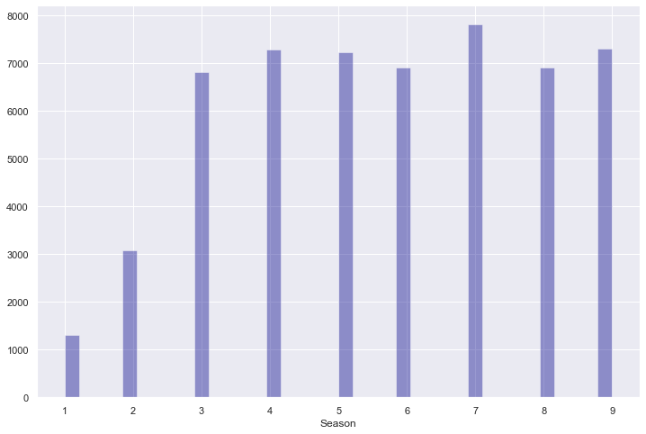

```python
sns.set()
sns.distplot(df['Season'], kde=False, color = 'darkblue')
```

**Season 7** has the biggest number of lines. **Season 1** has the smallest number but it is expected given the number of episodes per season. We can also check the number of episodes!

```python
episode_count = df.groupby('Season')['SEID'].aggregate(['count', 'unique'])
episode_count['episodes'] = episode_count['unique'].apply(lambda x: len(x))
episode_count[['count', 'episodes']]
```

| Season | count | episodes |
| --- | --- | --- |
| 1.0 | 1308 | 4 |
| 2.0 | 3077 | 12 |
| 3.0 | 6811 | 23 |
| 4.0 | 7285 | 24 |
| 5.0 | 7228 | 21 |
| 6.0 | 6903 | 22 |
| 7.0 | 7806 | 24 |
| 8.0 | 6895 | 22 |
| 9.0 | 7293 | 21 |

**Season 7** has the highest episode_count == 24 and **Season 1** the lowest == 4. However, if we look at Seinfeld's wikipedia page [https://en.wikipedia.org/wiki/Seinfeld#Episodes] we can notice that Season 1 has 5 episodes and not 4. By looking at the dataset again, we can notice that both Pilot episodes are merged and labeled as the same episode 'S01E01'. Now, we need to find the ending of the first pilot within S01E01 and divide them into two separate episodes. We can make our lives easier by dividing the total number of lines with the number of episodes and get an approximate line per episode measure.

```python
#Number of lines of dialogue per episode
episode_count['count']/episode_count['episodes']
```

```
Season
1.0    327.000000
2.0    256.416667
3.0    296.130435
4.0    303.541667
5.0    344.190476
6.0    313.772727
7.0    325.250000
8.0    313.409091
9.0    347.285714
dtype: float64
```

We can see that season 1 has approximately 327 lines per episode. It is obvious that we should look in the range of 250 to 350 lines in the first episode of the first season to find the ending of the first Pilot episode and the beginning of the second one which is nested in it.

```python
df[250:350]
```

|  | Character | Dialogue | EpisodeNo | SEID | Season |
| --- | --- | --- | --- | --- | --- |
| 250 | ELAINE | Cmon lets go... | 1.0 | S01E01 | 1.0 |
| 251 | JERRY | Was I supposed to bring something? | 1.0 | S01E01 | 1.0 |
| 252 | ELAINE | You could have. | 1.0 | S01E01 | 1.0 |
| 253 | JERRY | I met her one time... | 1.0 | S01E01 | 1.0 |
| 254 | ELAINE | It is not necessary. | 1.0 | S01E01 | 1.0 |
| ... | ... | ... | ... | ... | ... |
| 345 | HELEN | I know what it was. | 1.0 | S01E01 | 1.0 |
| 346 | JERRY | You dont know what it was. | 1.0 | S01E01 | 1.0 |
| 347 | HELEN | So, what was it? | 1.0 | S01E01 | 1.0 |
| 348 | JERRY | Well, we fight a lot for some reason. | 1.0 | S01E01 | 1.0 |
| 349 | HELEN & MORTY | Oh, well... | 1.0 | S01E01 | 1.0 |

100 rows × 5 columns

Being a fan of the TV show, I notice that the second pilot has already started. We need to look in the range between 200 and 250.

```python
df[200:250]
```

|  | Character | Dialogue | EpisodeNo | SEID | Season |
| --- | --- | --- | --- | --- | --- |
| 200 | LAURA | (to the phone) Hello?... Hi!... No no it was g... | 1.0 | S01E01 | 1.0 |
| 201 | JERRY | (not excited) Youre engaged? | 1.0 | S01E01 | 1.0 |
| 202 | LAURA | You, you really have no idea what its like unt... | 1.0 | S01E01 | 1.0 |
| 203 | JERRY | Youre engaged? | 1.0 | S01E01 | 1.0 |
| 204 | LAURA | You know, I cant believe it myself sometimes. ... | 1.0 | S01E01 | 1.0 |
| 205 | JERRY | (matter-of-factly) Youre engaged. | 1.0 | S01E01 | 1.0 |
| 206 | LAURA | Yeah, yeah, hes a great guy... | 1.0 | S01E01 | 1.0 |
| 207 | JERRY | Yeah. | 1.0 | S01E01 | 1.0 |
| 208 | LAURA | Youd really like him, you know, I cant wait to... | 1.0 | S01E01 | 1.0 |
| 209 | JERRY | Me too! | 1.0 | S01E01 | 1.0 |
| 210 | JERRY | I swear, I have absolutely no idea what women ... | 1.0 | S01E01 | 1.0 |
| 211 | JERRY | So, Im on line at the supermarket. Two women i... | 1.0 | S01E01 | 1.0 |
| 212 | AUDIENCE | Cheque. | 1.0 | S01E01 | 1.0 |
| 213 | JERRY | Cheque. Now, the fact is, if its a woman in fr... | 1.0 | S01E01 | 1.0 |
| 214 | JERRY | Whats that one? | 1.0 | S01E01 | 1.0 |
| 215 | ELAINE | Coccoon II The Return. I guess they didnt like... | 1.0 | S01E01 | 1.0 |
| 216 | JERRY | Maybe they came back for Chinese food. Yknow M... | 1.0 | S01E01 | 1.0 |
| 217 | ELAINE | Okay, whatre we doing here? I have seen everyt... | 1.0 | S01E01 | 1.0 |
| 218 | JERRY | Oh yeah? I dont believe youve seen... this. | 1.0 | S01E01 | 1.0 |
| 219 | ELAINE | Oh, lovely. | 1.0 | S01E01 | 1.0 |
| 220 | JERRY | Yeah. | 1.0 | S01E01 | 1.0 |
| 221 | ELAINE | What do you think their parents think? | 1.0 | S01E01 | 1.0 |
| 222 | JERRY | So, uh, whats your son doing now, Dr. Stevens?... | 1.0 | S01E01 | 1.0 |
| 223 | ELAINE | Yknow what? This would be a really funny gift ... | 1.0 | S01E01 | 1.0 |
| 224 | JERRY | Pamela? Do I know her? | 1.0 | S01E01 | 1.0 |
| 225 | ELAINE | Yeah, you met her when we were going out. | 1.0 | S01E01 | 1.0 |
| 226 | JERRY | Oh yeah, right... | 1.0 | S01E01 | 1.0 |
| 227 | ELAINE | You have no idea who Im talking about, do you? | 1.0 | S01E01 | 1.0 |
| 228 | JERRY | (quickly) No. | 1.0 | S01E01 | 1.0 |
| 229 | ELAINE | Blonde hair, remember? Glasses? (pause) Have y... | 1.0 | S01E01 | 1.0 |
| 230 | JERRY | (a lightbulb goes on in his head) Riverside Dr... | 1.0 | S01E01 | 1.0 |
| 231 | ELAINE | Right! In fact... No, never mind... | 1.0 | S01E01 | 1.0 |
| 232 | JERRY | Well, what is it? | 1.0 | S01E01 | 1.0 |
| 233 | ELAINE | Well, a bunch of people are getting together t... | 1.0 | S01E01 | 1.0 |
| 234 | JERRY | Wait a second, wait a second. We could work ou... | 1.0 | S01E01 | 1.0 |
| 235 | ELAINE | What little deal? | 1.0 | S01E01 | 1.0 |
| 236 | JERRY | I will go to that, if you go with me to a litt... | 1.0 | S01E01 | 1.0 |
| 237 | ELAINE | A wedding? Have you lost it, man? | 1.0 | S01E01 | 1.0 |
| 238 | JERRY | Yknow, my parents are coming in for this... | 1.0 | S01E01 | 1.0 |
| 239 | ELAINE | Theyre coming in? | 1.0 | S01E01 | 1.0 |
| 240 | JERRY | Yeah, tomorrow. | 1.0 | S01E01 | 1.0 |
| 241 | ELAINE | Hey, did your father ever get that hair weave? | 1.0 | S01E01 | 1.0 |
| 242 | JERRY | No, no. Still doin the big sweep across. | 1.0 | S01E01 | 1.0 |
| 243 | ELAINE | Why does he do that? | 1.0 | S01E01 | 1.0 |
| 244 | JERRY | Doesnt think anyone can tell. So cmon, do we h... | 1.0 | S01E01 | 1.0 |
| 245 | ELAINE | A wedding? | 1.0 | S01E01 | 1.0 |
| 246 | JERRY | Theres a lot of people to mock... | 1.0 | S01E01 | 1.0 |
| 247 | ELAINE | All right, what the hell. | 1.0 | S01E01 | 1.0 |
| 248 | JERRY | Great! | 1.0 | S01E01 | 1.0 |
| 249 | WOMAN | When youre dead, youre dead. Thats it. Youre n... | 1.0 | S01E01 | 1.0 |

Jerry's monologue about not understanding women ends the first pilot at the line 210. Hence we need to label first 210 differently to separate the two pilot episodes.

```python
df[0:211]['SEID'] = 'Pilot 1' #Remember that 211 is not included in the range
```

# Data Visualisation

## Plot number of lines per character

Define the color palette and assign it to variable col.

Define the function plot_lines which will plot the most frequent 9 characters in the TV show, by the number of lines.

```python
col = sns.color_palette("Paired", 9)
def plot_lines(season = None, episode = None, top_n = 9):
    filtered_scripts = df
    if season:
        filtered_scripts = filtered_scripts[filtered_scripts['Season'] == season]
    if episode:
        filtered_scripts = filtered_scripts[filtered_scripts['SEID'] == episode]
    filtered_scripts['Character'].value_counts().head(top_n).plot(kind = 'bar', color=col, title = 'Number of lines per character', figsize=(16,10))
```

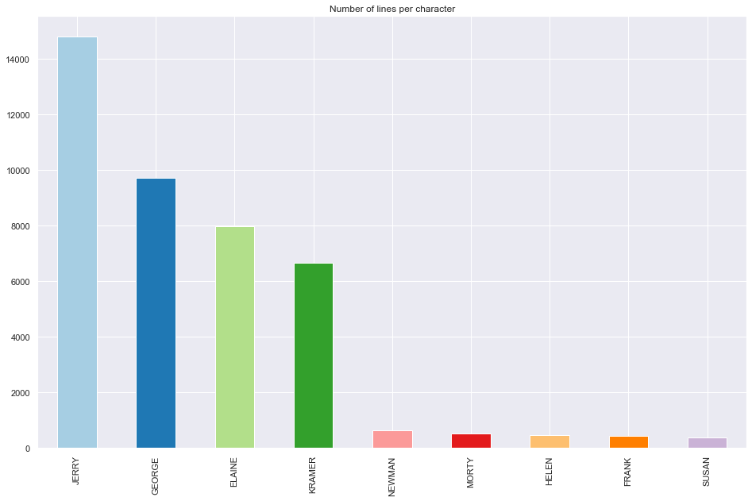

```python
sns.set()
plot_lines()
```

```python
line_count = df['Character'].value_counts().head(7)
line_count
characters = ['JERRY', 'GEORGE', 'ELAINE', 'KRAMER', 'NEWMAN', 'MORTY', 'HELEN']
characters
```

```
['JERRY', 'GEORGE', 'ELAINE', 'KRAMER', 'NEWMAN', 'MORTY', 'HELEN']
```

```python
from bokeh.io import show, output_notebook
from bokeh.plotting import figure
from bokeh.palettes import brewer
colors = brewer["Dark2"][len(characters)]

output_notebook()

p = figure(x_range=characters, plot_height=600, plot_width=700,
           title="Number of lines in the script per main character", toolbar_location=None, tools="")

p.vbar(x=characters, top=line_count, width=0.9, color = colors)

p.xgrid.grid_line_color = None
p.y_range.start = 0

show(p)
```

[interactive chart not shown]